# learning form data : wine_report

Harry Liou

## 目錄：緒論、資料與方法（切割資料、配適模型）、預測結果

### 資料介紹

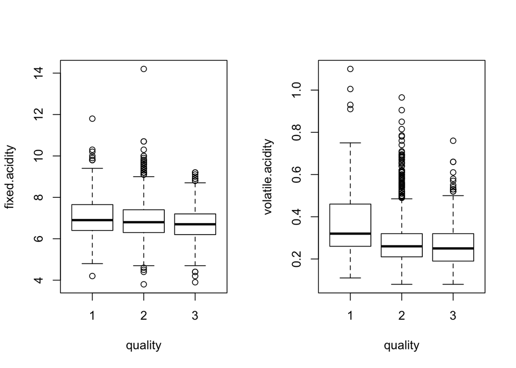

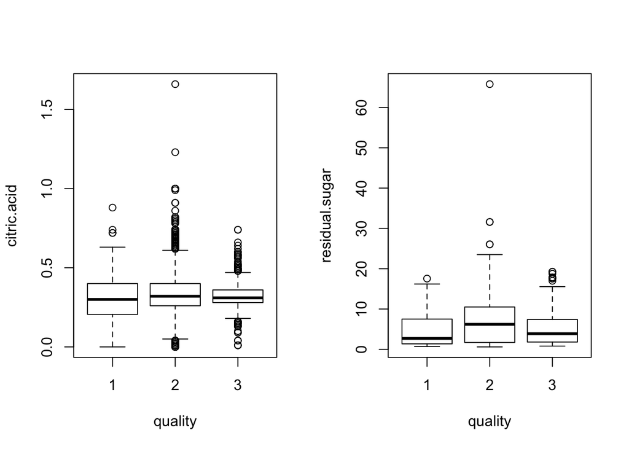

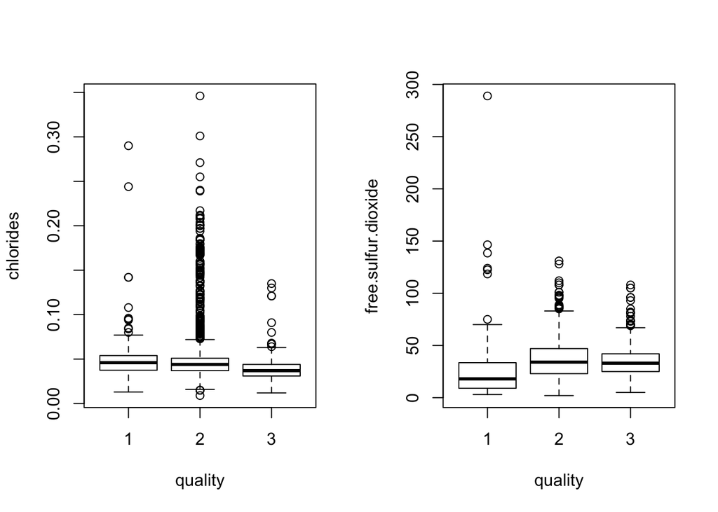

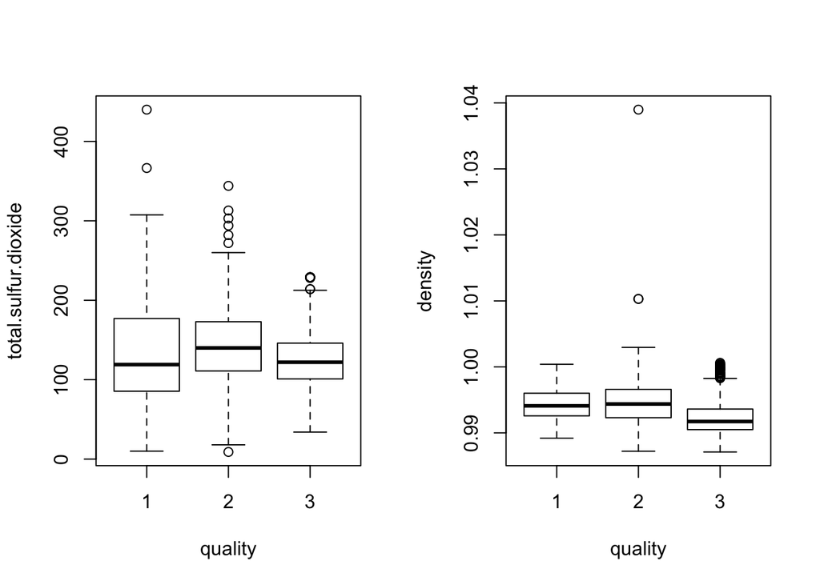

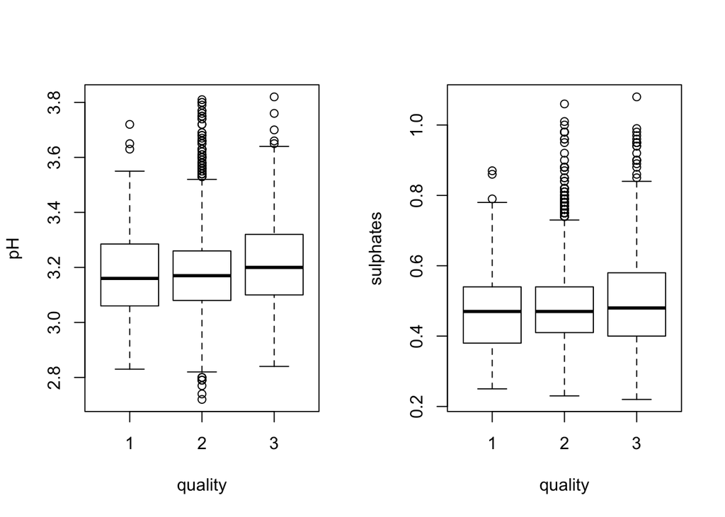

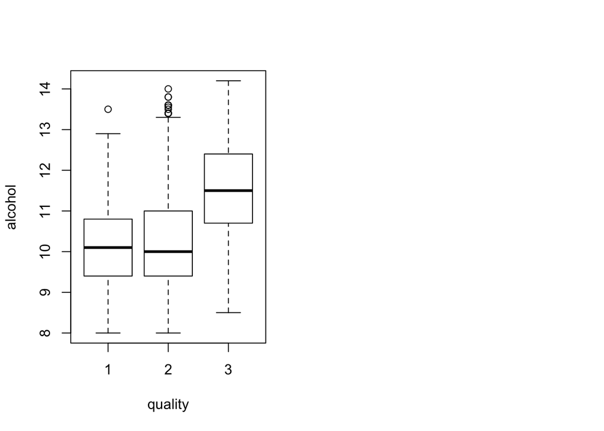

### 資料整理

此筆資料的葡萄酒品質等級為1到10。其中，等級0、1、2、10沒有資料。 為了分析方便，我將以3 ~ 4分為一組；5,6為一組，7 ~ 9為一組。

### 交叉驗證

我使用10-fold cross-validation來做交叉驗證。切割資料的方法是先將原始資料的排序打亂（r code：sample），得到一筆順序重新排列過的資料。然後依照新的順序將第一筆資料放進第一個subset，第二筆資料放進第二個subset，依此類推，以十筆一個循環，第十一筆又分到第一個subset。共10個subset。 交叉驗證每次使用一個subset作為testing data，其餘9個subset作為training data。所以共會做十次training and testing. 為了保持每個subset的中quality的三個類別的比例，在做cross-validation時會先將原始資料以quality的類別分開再做10-fold，所以會得到3*10個subset。再將三個類別中各自的第一個subset合成一筆新的subset，第二個subset合成一筆新的subset，依此類推，就得到十個大小相同、quality的三個類別比例相同的subset。

### 配適模型

我使用羅吉斯迴歸（logistic regression）作為分類模型。 由於品質有三個類別，所以我採用voting的策略，本次分析做了 one versus one 以及one versus others。無論是one versus one 或是one versus others皆需配適三個迴歸模型，以下我們先介紹one versus one 以及one versus others的voting 策略，再介紹迴歸模型。

### one versus one

三個類別兩兩做一次compete共會產生八種可能的結果。分別為：

1. 1>2, 1>3, 2>3
2. 1>2, 1>3, 2<3
3. 2>3, 2>1, 1>3
4. 1>3, 2>1, 1<3
5. 3>1, 3>2, 1>2
6. 3>1, 3>2, 1<2
7. 1>2>3>1
8. 1<2<3<1

其中，a、b種情況沒有爭議是1勝出，c、d種情況是2勝出，e、f種情況是3勝出。g、h種情況則是較有爭議的。我們決定以 P( Yi |Xi , Xj )*P(Xi , Xj | Xi, Xj, Xk) = P( Yi ) 的值來做最後的比較，P( Yi )值最大者該competition則由i勝出。（如：若P( Y1 )> P( Y2 )且P( Y1 ) >P( Y3)，則由1勝出）

### one versus others

可能的分類結果有三種:

1. 1 vs others
2. 2 vs others
3. 3 vs others 以三者的P( Yi )值做比較，最大者該competition則由i勝出。（如：若P( Y1 )> P( Y2 )且P( Y1 ) >P( Y3)，則由1勝出）

### 模型介紹

```
##
## Call:
## glm(formula = train_data_w$quality ~ ., family = binomial(link = "logit"),
##     data = train_data_w)
##
## Deviance Residuals:
##     Min       1Q   Median       3Q      Max
## -3.6604   0.0914   0.1989   0.4079   2.0145
##
## Coefficients:
##                        Estimate Std. Error z value Pr(>|z|)
## (Intercept)           1.217e+03  2.484e+02   4.898 9.68e-07 ***
## fixed.acidity         4.599e-01  2.537e-01   1.813 0.069853 .
## volatile.acidity     -1.264e+01  1.420e+00  -8.902  < 2e-16 ***
## citric.acid          -3.404e-01  1.235e+00  -0.276 0.782844
## residual.sugar        6.714e-01  9.909e-02   6.776 1.24e-11 ***
## chlorides            -4.356e+00  9.471e+00  -0.460 0.645543
## free.sulfur.dioxide   8.486e-03  8.777e-03   0.967 0.333606
## total.sulfur.dioxide  5.448e-03  4.358e-03   1.250 0.211280
## density              -1.247e+03  2.522e+02  -4.943 7.69e-07 ***
## pH                    5.191e+00  1.227e+00   4.231 2.33e-05 ***
## sulphates             4.034e+00  1.184e+00   3.408 0.000654 ***
## alcohol               1.112e-01  3.086e-01   0.360 0.718522
## ---
## Signif. codes:  0 '***' 0.001 '**' 0.01 '*' 0.05 '.' 0.1 ' ' 1
##
## (Dispersion parameter for binomial family taken to be 1)
##
##     Null deviance: 955.42  on 1124  degrees of freedom
## Residual deviance: 517.13  on 1113  degrees of freedom
## AIC: 541.13
##
## Number of Fisher Scoring iterations: 6
```

### 預測結果

#### one versus one

準確率矩陣(row:pred, col:true)

```
##      [,1]  [,2] [,3]
## [1,]  0.6   0.9  0.0
## [2,] 16.7 365.3 98.2
## [3,]  0.3   2.5  5.3
```

準確率

```
##    Min. 1st Qu.  Median    Mean 3rd Qu.    Max.
##  0.7449  0.7580  0.7592  0.7585  0.7617  0.7633
```

#### one versus others

準確率矩陣(row:pred, col:true)

```
##      [,1]  [,2] [,3]
## [1,]  0.2   0.1  0.0
## [2,] 17.1 345.3 79.6
## [3,]  0.2  17.0 30.5
```

準確率

```
##    Min. 1st Qu.  Median    Mean 3rd Qu.    Max.
##  0.7612  0.7617  0.7646  0.7656  0.7673  0.7776
```